# Introduction to arrays in numpy

The "numpy" is the efficient numerical computation library of python. We start with defining arrays and their basic manipulation. Arrays are like lists except their type is fixed for each element. The common types are `int` and `float`. We start with a one dimensional array of size 3.

```python
import numpy as np

a = np.array([1, 2, 3])
print type(a)
print a.shape
print a
```

```
<type 'numpy.ndarray'>
(3,)
[1 2 3]
```

Now we define a two-dimensional array of size 2$\times$3

```python
b = np.array([[1,2,3],[4,5,6]])
print b.shape
print b[1, :]
```

```
(2, 3)
[4 5 6]
```

Any time you need help you can write "numpy.array?", you may initialize a matrix using "numpy.full"

```python
print np.full((2,3),7)
```

```
[[ 7.  7.  7.]
 [ 7.  7.  7.]]
```

This initializes a 2$\times$3 with value float 7.0. try other functions like `numpy.zeros`, `numpy.ones`, and `numpy.eye`

## Boolean array indexing

Using the boolean array indexing you pick up the elements of an array. This type of indexing helps you to select the elements of an array that satisfy a condition. You must be aware that arrays in numpy is different from lists in python. However, we can convert a numeric list to a numpy array using `np.array`

```python
import numpy as np
a = np.array([[1,2], [3, 4], [5, 6]])
print (a > 2)
print a[a>2]
```

```
[[False False]
 [ True  True]
 [ True  True]]
[3 4 5 6]
```

## Exercise

Produce an identity matrix of size 10 and replace the diagonal elements with 1 to 10.

```python
myarray=np.eye(10)
myarray[myarray==1]=range(1,len(myarray)+1)
print myarray
```

```
[[  1.   0.   0.   0.   0.   0.   0.   0.   0.   0.]
 [  0.   2.   0.   0.   0.   0.   0.   0.   0.   0.]
 [  0.   0.   3.   0.   0.   0.   0.   0.   0.   0.]
 [  0.   0.   0.   4.   0.   0.   0.   0.   0.   0.]
 [  0.   0.   0.   0.   5.   0.   0.   0.   0.   0.]
 [  0.   0.   0.   0.   0.   6.   0.   0.   0.   0.]
 [  0.   0.   0.   0.   0.   0.   7.   0.   0.   0.]
 [  0.   0.   0.   0.   0.   0.   0.   8.   0.   0.]
 [  0.   0.   0.   0.   0.   0.   0.   0.   9.   0.]
 [  0.   0.   0.   0.   0.   0.   0.   0.   0.  10.]]
```

```python
np.set_printoptions(suppress=True)
print (2**myarray)-1
```

```
[[    1.     0.     0.     0.     0.     0.     0.     0.     0.     0.]
 [    0.     3.     0.     0.     0.     0.     0.     0.     0.     0.]
 [    0.     0.     7.     0.     0.     0.     0.     0.     0.     0.]
 [    0.     0.     0.    15.     0.     0.     0.     0.     0.     0.]
 [    0.     0.     0.     0.    31.     0.     0.     0.     0.     0.]
 [    0.     0.     0.     0.     0.    63.     0.     0.     0.     0.]
 [    0.     0.     0.     0.     0.     0.   127.     0.     0.     0.]
 [    0.     0.     0.     0.     0.     0.     0.   255.     0.     0.]
 [    0.     0.     0.     0.     0.     0.     0.     0.   511.     0.]
 [    0.     0.     0.     0.     0.     0.     0.     0.     0.  1023.]]
```

## Matrix operations

### Elementwise operation

Element-wise matrix operations are as follows Take

$x=\left(\begin{array}{c c} 1&2\\3&4 \end{array}\right) ~~~~$ $y=\left(\begin{array}{c c} 5&6\\7&8 \end{array}\right)$

```python
x = np.array([[1,2],[3,4]], dtype=np.float64)
y = np.array([[5,6],[7,8]], dtype=np.float64)
print x + y
print np.add(x, y)
```

```
[[  6.   8.]
 [ 10.  12.]]
[[  6.   8.]
 [ 10.  12.]]
```

```python
print x - y
print np.subtract(x, y)
```

```
[[-4. -4.]
 [-4. -4.]]
[[-4. -4.]
 [-4. -4.]]
```

```python
print x * y
print np.multiply(x, y)
```

```
[[  5.  12.]
 [ 21.  32.]]
[[  5.  12.]
 [ 21.  32.]]
```

```python
print x / y
print np.divide(x, y)
```

```
[[ 0.2         0.33333333]
 [ 0.42857143  0.5       ]]
[[ 0.2         0.33333333]
 [ 0.42857143  0.5       ]]
```

### Dot product

Matrix product is the "dot operator. It can be used with only one, or two arguments

```python
print x.dot(y)
print np.dot(x,y)
```

```
[[ 19.  22.]
 [ 43.  50.]]
[[ 19.  22.]
 [ 43.  50.]]
```

### Matrix sum

The sum of a matrix can be implemented on rows, on columns, or on the total matrix.

```python
print np.sum(x, axis=1) # on rows
print np.sum(x, axis=0) # on columns
print np.sum(x)  # on both
```

```
[ 3.  7.]
[ 4.  6.]
10.0
```

### Matrix transpose

The function for transposing a matrix is .T

```python
print x.T
print np.sum(x.T,axis=0) # gives sum over rows (and not columns even with axis=0)
```

```
[[ 1.  3.]
 [ 2.  4.]]
[ 3.  7.]
```

### Repeating a matrix

repeating a matrix several times on rows and columns. This is a special case of the kronecker product

```python
print np.tile(x,(2,3))
```

```
[[ 1.  2.  1.  2.  1.  2.]
 [ 3.  4.  3.  4.  3.  4.]
 [ 1.  2.  1.  2.  1.  2.]
 [ 3.  4.  3.  4.  3.  4.]]
```

### Reshaping a matrix

```python
print np.reshape(range(10),(2,5) )
```

```
[[0 1 2 3 4]
 [5 6 7 8 9]]
```

```python
print np.reshape(range(10),(5,2) )
```

```
[[0 1]
 [2 3]
 [4 5]
 [6 7]
 [8 9]]
```

Now we lets use some image libraries and plot some pictures.

```
(-0.5, 247.5, 399.5, -0.5)
```

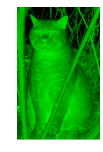

```python
import matplotlib.pylab as plt
%matplotlib inline
#url=http://cs231n.github.io/assets/cat.jpg
img = plt.imread('../data/cat.jpg')
img_tinted = img * [0, 1, 0]
plt.imshow(img_tinted)
plt.axis("off")
```

```
(-0.5, 247.5, 399.5, -0.5)
```

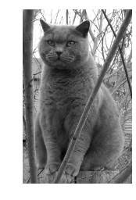

```python
img_tinted = img * [.27, .72, 0.07]
plt.imshow(np.sum(img_tinted, axis=2), "gray")
plt.axis("off")
```